# assignment3

Siqi, Arnav, Ruini

30/10/2021

# Question 1

## Q1.1

```r
read.csv("single_cell_RNA_seq_bam.sam", nrows=73, sep="\t", header=FALSE, fill=TRUE)
```

```
##                     V1
## 1                  @HD
## 2                  @SQ
## 3                  @SQ
## 4                  @SQ
## 5                  @SQ
## 6                  @SQ
## 7                  @SQ
## 8                  @SQ
## 9                  @SQ
## 10                 @SQ
## 11                 @SQ
## 12                 @SQ
## 13                 @SQ
## 14                 @SQ
```

[output cut: 210 more lines]

SN reference sequence name. LN reference sequence length.

## Q1.2

LN:171031299. The length of X chromosome 171031299 bp.

# Question2

## Q2.1

```r
sam <- read.csv("single_cell_RNA_seq_bam.sam", sep="\t", header=FALSE, comment.char="@", col.names = paste0("V",seq_len(30)), fill=TRUE)
sam <- sam[paste0("V",seq_len(11))]
```

There are 146346 reads in this BAM file.

## Q2.2

```r
sam[10:10,]
```

```
##                                           V1 V2 V3      V4  V5  V6 V7 V8 V9
## 10 NS500668:199:HV73CBGX2:1:11203:20546:3351 16  1 3365976 255 58M  *  0  0
##                                                           V10
## 10 AATCAAAAAGGGGGCTGTCAGTAGGATGATATAAGATATAGATGTAGTTTATCTCCTA
##                                                           V11
## 10 EEEEEEEEEEA//AAAAEEEEEE/AEEAEAEEEEEEEEEEEEEAAEE///EEEAAA6A
```

We should look at column “V3” to find the chromosome to which the read was aligned. V11 correspond to QUAL field in BAM file.

## Q2.3

```r
Xchrom <- sam$V3 == "X"
sum(Xchrom)
```

```
## [1] 5999
```

There are 5999 reads align to chromosome X.

## Q2.4

```r
#Turn Phred+33 ASCII‐encoded quality into Q
sam_x <- sam[Xchrom,]
bqXchrom <- sam_x$V11
bqXvals <- c()
for (i in 1:length(bqXchrom))
  bqXvals[i] <- mean(utf8ToInt(bqXchrom[i])-33)
mean(bqXvals)
```

```
## [1] 32.72349
```

The mean base quality value of all X chromosome aligned reads is 32.72349

## Q2.5

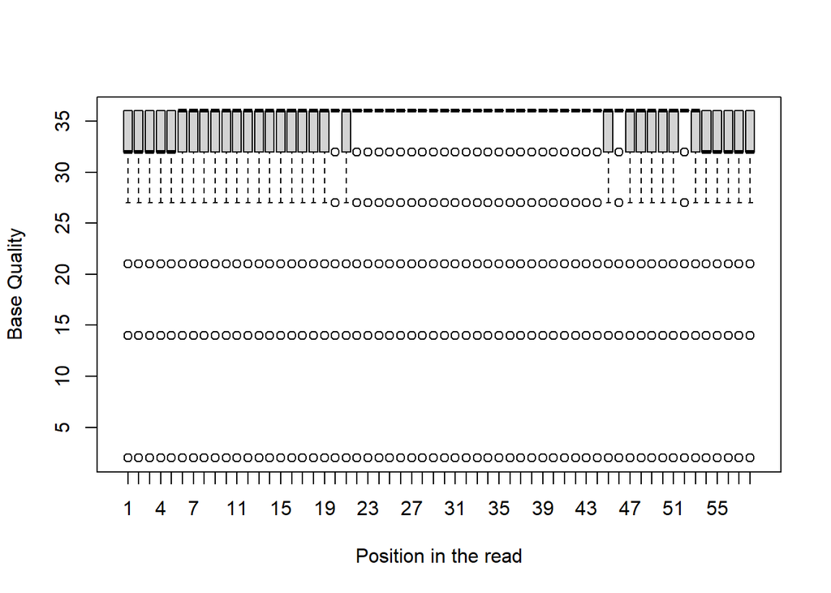

```r
library(ggplot2)

BQ <- matrix(nrow = nrow(sam), ncol = length(utf8ToInt(bqXchrom[i])-33)) #rows = reads, ncol = 58
for(i in 1:58)
  for(j in 1:nrow(sam))
    BQ[j,i] <- utf8ToInt(sam[j,11])[i] -33
boxplot(BQ, xlab = "Position in the read", ylab = "Base Quality")
```

The distributions of base qualities are all concentrated between 30-37.

## Q2.6

Column ‘V4’ contains the leftmost mapping position of the reads.

## Q2.7

```r
chrom9 <- c()
chrom9 <- sam$V3 == "9" #find chromosome 9
pos <- sam[chrom9,]
sum(pos$V4 > 40801273 & pos$V4 < 40805199)
```

```
## [1] 119
```

There are 119 reads have their leftmost mapping position aligned within these coordinates.

## Q2.8

```r
mq = sam$V5 < 50
sum(mq)
```

```
## [1] 61527
```

There are 61527 reads have mapping quality less than 50.

## Q2.9

```r
m <- subset(sam,sam$V5<50)
mean(m$V5)
```

```
## [1] 0.2418125
```

The mean mapping quality is 0.2418125.

# Question 3

## Q3.1

```r
vcf_con <- file("RNA_seq_annotated_variants.vcf", open="r")
vcf_file <- readLines(vcf_con)
close(vcf_con)
vcf <- data.frame(vcf_file)
header <- vcf[grepl("##", vcf$vcf_file), ]
factor(header)
```

```
##   [1] ##fileformat=VCFv4.1
##   [2] ##fileDate=20200930
##   [3] ##source=strelka
##   [4] ##source_version=2.9.2
##   [5] ##startTime=Wed Sep 30 13:12:59 2020
##   [6] ##contig=<ID=1,length=195471971>
##   [7] ##contig=<ID=10,length=130694993>
##   [8] ##contig=<ID=11,length=122082543>
##   [9] ##contig=<ID=12,length=120129022>
##  [10] ##contig=<ID=13,length=120421639>
##  [11] ##contig=<ID=14,length=124902244>
##  [12] ##contig=<ID=15,length=104043685>
##  [13] ##contig=<ID=16,length=98207768>
##  [14] ##contig=<ID=17,length=94987271>
##  [15] ##contig=<ID=18,length=90702639>
```

[output cut: 96 more lines]

```r
variants <- read.csv("RNA_seq_annotated_variants.vcf", skip=length(header), header=TRUE, sep="\t")
```

## Q3.2

```r
ref <- (grep("SNVHPOL=16",variants$INFO))
FST <- variants[ref[1],8]
ANN <- strsplit(FST,";")
ANN[[1]][3]
```

```
## [1] "ANN=A|intron_variant|MODIFIER|Sulf1|ENSMUSG00000016918|transcript|ENSMUST00000088585.9|protein_coding|2/21|c.-133+17418G>A||||||,A|intron_variant|MODIFIER|Sulf1|ENSMUSG00000016918|transcript|ENSMUST00000177608.7|protein_coding|2/21|c.-133+17418G>A||||||,A|intron_variant|MODIFIER|Sulf1|ENSMUS…
```

## Q3.3

```r
ID_ANN <- grep("INFO=<ID=ANN", vcf$vcf_file)
vcf[ID_ANN,]
```

```
## [1] "##INFO=<ID=ANN,Number=.,Type=String,Description=\"Functional annotations: 'Allele | Annotation | Annotation_Impact | Gene_Name | Gene_ID | Feature_Type | Feature_ID | Transcript_BioType | Rank | HGVS.c | HGVS.p | cDNA.pos / cDNA.length | CDS.pos / CDS.length | AA.pos / AA.length | Distance |…
```

```r
strsplit(variants[1,8],",")
```

```
## [[1]]
## [1] "SNVHPOL=16;MQ=255;ANN=A|intron_variant|MODIFIER|Sulf1|ENSMUSG00000016918|transcript|ENSMUST00000088585.9|protein_coding|2/21|c.-133+17418G>A||||||"
## [2] "A|intron_variant|MODIFIER|Sulf1|ENSMUSG00000016918|transcript|ENSMUST00000177608.7|protein_coding|2/21|c.-133+17418G>A||||||"
## [3] "A|intron_variant|MODIFIER|Sulf1|ENSMUSG00000016918|transcript|ENSMUST00000180062.7|protein_coding|1/20|c.-132-39973G>A||||||"
## [4] "A|intron_variant|MODIFIER|Sulf1|ENSMUSG00000016918|transcript|ENSMUST00000186051.6|protein_coding|2/21|c.-133+17418G>A||||||"
## [5] "A|intron_variant|MODIFIER|Sulf1|ENSMUSG00000016918|transcript|ENSMUST00000187376.6|retained_intron|2/11|n.420+17418G>A||||||"
## [6] "A|intron_variant|MODIFIER|Sulf1|ENSMUSG00000016918|transcript|ENSMUST00000186405.6|protein_coding|1/2|c.-133+17418G>A||||||WARNING_TRANSCRIPT_INCOMPLETE"
## [7] "A|intron_variant|MODIFIER|Sulf1|ENSMUSG00000016918|transcript|ENSMUST00000189541.6|protein_coding|2/3|c.-133+17418G>A||||||WARNING_TRANSCRIPT_INCOMPLETE"
```

This variant is intron variant from the ‘Annotation’ field.

## Q3.4

```r
vcf_con <- file("RNA_seq_annotated_variants.vcf", open="r")
vcf_file <- readLines(vcf_con)
close(vcf_con)
vcf <- data.frame(vcf_file)
header <- vcf[grepl("##", vcf$vcf_file), ]
factor(header)
```

```
##   [1] ##fileformat=VCFv4.1
##   [2] ##fileDate=20200930
##   [3] ##source=strelka
##   [4] ##source_version=2.9.2
##   [5] ##startTime=Wed Sep 30 13:12:59 2020
##   [6] ##contig=<ID=1,length=195471971>
##   [7] ##contig=<ID=10,length=130694993>
##   [8] ##contig=<ID=11,length=122082543>
##   [9] ##contig=<ID=12,length=120129022>
##  [10] ##contig=<ID=13,length=120421639>
##  [11] ##contig=<ID=14,length=124902244>
##  [12] ##contig=<ID=15,length=104043685>
##  [13] ##contig=<ID=16,length=98207768>
##  [14] ##contig=<ID=17,length=94987271>
##  [15] ##contig=<ID=18,length=90702639>
```

[output cut: 96 more lines]

```r
variants <- read.csv("RNA_seq_annotated_variants.vcf", skip=length(header), header=TRUE, sep="\t")
ref <- (grep("SNVHPOL=16",variants$INFO))
FST <- variants[ref[683],8]
ANN <- strsplit(FST,";")
ANN[[1]][3]
```

```
## [1] NA
```

```r
grep("INFO=<ID=ANN", vcf$vcf_file)
```

```
## [1] 108
```

```r
vcf[grep("INFO=<ID=ANN", vcf$vcf_file),]
```

```
## [1] "##INFO=<ID=ANN,Number=.,Type=String,Description=\"Functional annotations: 'Allele | Annotation | Annotation_Impact | Gene_Name | Gene_ID | Feature_Type | Feature_ID | Transcript_BioType | Rank | HGVS.c | HGVS.p | cDNA.pos / cDNA.length | CDS.pos / CDS.length | AA.pos / AA.length | Distance |…
```

```r
strsplit(variants[683,8],",")
```

```
## [[1]]
##  [1] "CIGAR=1M6D;RU=CAGGGG;REFREP=1;IDREP=0;MQ=0;ANN=A|frameshift_variant&splice_acceptor_variant&splice_region_variant&intron_variant|HIGH|Rps19|ENSMUSG00000040952|transcript|ENSMUST00000108428.7|protein_coding|5/5|c.357-2_360delAGGGGC|p.Gly120fs||357/639|119/212||INFO_REALIGN_3_PRIME"
##  [2] "A|frameshift_variant&splice_acceptor_variant&splice_region_variant&intron_variant|HIGH|Rps19|ENSMUSG00000040952|transcript|ENSMUST00000108430.9|protein_coding|5/6|c.357-2_360delAGGGGC|p.Gly120fs||357/438|119/145||INFO_REALIGN_3_PRIME"
##  [3] "A|frameshift_variant&splice_acceptor_variant&splice_region_variant&intron_variant|HIGH|Rps19|ENSMUSG00000040952|transcript|ENSMUST00000108429.7|protein_coding|5/6|c.357-2_360delAGGGGC|p.Gly120fs||357/438|119/145||INFO_REALIGN_3_PRIME"
##  [4] "A|frameshift_variant&splice_acceptor_variant&splice_region_variant&intron_variant|HIGH|Rps19|ENSMUSG00000040952|transcript|ENSMUST00000156372.7|protein_coding|5/5|c.390-2_393delAGGGGC|p.Gly131fs||390/413|130/136||WARNING_TRANSCRIPT_INCOMPLETE&INFO_REALIGN_3_PRIME"
##  [5] "A|frameshift_variant&splice_acceptor_variant&splice_region_variant&intron_variant|HIGH|Rps19|ENSMUSG00000040952|transcript|ENSMUST00000124035.1|protein_coding|4/4|c.465-2_468delAGGGGC|p.Gly156fs||465/530|155/175||WARNING_TRANSCRIPT_INCOMPLETE&INFO_REALIGN_3_PRIME"
##  [6] "A|frameshift_variant&splice_acceptor_variant&splice_region_variant&intron_variant|HIGH|Rps19|ENSMUSG00000040952|transcript|ENSMUST00000153451.8|protein_coding|5/5|c.357-2_360delAGGGGC|p.Gly120fs||357/400|119/132||WARNING_TRANSCRIPT_INCOMPLETE&INFO_REALIGN_3_PRIME"
##  [7] "A|splice_acceptor_variant&3_prime_UTR_variant&intron_variant|HIGH|Rps19|ENSMUSG00000040952|transcript|ENSMUST00000129847.7|nonsense_mediated_decay|6/7|c.*219-2_*222delAGGGGC|||||2752|INFO_REALIGN_3_PRIME"
##  [8] "A|splice_acceptor_variant&splice_region_variant&intron_variant&non_coding_transcript_exon_variant|HIGH|Rps19|ENSMUSG00000040952|transcript|ENSMUST00000130335.7|retained_intron|2/3|n.277-2_280delAGGGGC||||||INFO_REALIGN_3_PRIME"
##  [9] "A|splice_region_variant|LOW|Rps19|ENSMUSG00000040952|transcript|ENSMUST00000129847.7|nonsense_mediated_decay|6/7|c.*219-2_*222delAGGGGC||||||INFO_REALIGN_3_PRIME"
## [10] "A|downstream_gene_variant|MODIFIER|Rps19|ENSMUSG00000040952|transcript|ENSMUST00000138662.1|retained_intron||n.*1145_*1150delCAGGGG|||||1145|"
## [11] "A|non_coding_transcript_exon_variant|MODIFIER|Rps19|ENSMUSG00000040952|transcript|ENSMUST00000146004.1|processed_transcript|1/2|n.166_171delAGGGGC||||||INFO_REALIGN_3_PRIME"
## [12] "A|non_coding_transcript_variant|MODIFIER|Rps19|ENSMUSG00000040952|transcript|ENSMUST00000129847.7|nonsense_mediated_decay|6/7|c.*219-2_*222delAGGGGC||||||INFO_REALIGN_3_PRIME;LOF=(Rps19|ENSMUSG00000040952|10|0.60)"
```

This variant will affect gene Rps19.

## Q3.5

```r
variant_types <- strsplit(variants[,8],",")
variant_types <- do.call(c, variant_types)

numintrons <- length(grep("intron_variant", variant_types, value=FALSE))
numup <- length(grep("upstream_gene_variant", variant_types, value=FALSE))
numdown <- length(grep("downstream_gene_variant", variant_types, value=FALSE))
numintergenic <- length(grep("intergenic_region", variant_types, value=FALSE))
numutr <- length(grep("3_prime_UTR_variant", variant_types, value=FALSE))
nummissense <- length(grep("missense_variant", variant_types, value=FALSE))
numsyn <- length(grep("synonymous_variant", variant_types, value=FALSE))
numsplice <- length(grep("splice_region_variant", variant_types, value=FALSE))
numnoncod <- length(grep("non_coding_transcript_exon_variant", variant_types, value=FALSE))
numnoncod
```

```
## [1] 281
```

```r
# Adding up all the different categories gives us more than the length of variant_types (4065) because some variants belong to multiple types
```

## Q3.6

Frameshift variant is an insertion or deletion involving a number of base pairs that is not a multiple of three. It has a greater effect on the resultant protein than a missense variant. Because missense variant just changes an amino acid to another amino acid, but frameshift mutation deletes or inserts of a number of bases that is not a multiple of 3, which will cause lots of amino acid changes.

## Q3.7

```r
IV <- grepl("intron_variant", vcf$vcf_file)
sum(IV)
```

```
## [1] 476
```

There are 476 potential intronic variants.

## Q3.8

```r
#ideas: Get the extron index vector. Loop all the extron variants, check if its annotation has HIGH/MODERATE, record the gene name of it. Unique the names and list them.
intron <- grep("intron_variant", vcf$vcf_file)
```